# Alzheimer’s and Parkinson’s disease, Sleep and Mental Health

# Visualising the data

**The following code makes a grouped bar graph to show the mean length of sleep in minutes for each disease state for each of the five mental health categories.**

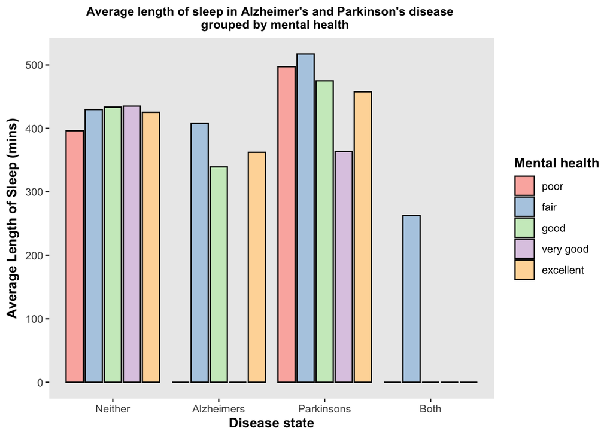

```r
p <- ggplot(df2, aes(x = disease_state, y = mean_sleep_length, fill = mental_health))
p + geom_col(color = 'black', position = position_dodge2(width=.9, preserve="single")) +
  labs(x = substitute(paste(bold("Disease state"))), y =
         substitute(paste(bold("Average Length of Sleep (mins)"))),
       title = "Average length of sleep in Alzheimer's and Parkinson's disease
  grouped by mental health") +
  theme(plot.title = element_text(hjust = 0.5, size = 10, face = "bold")) +
  theme(panel.grid.major = element_blank(), panel.grid.minor = element_blank()) +
  guides(fill = guide_legend(title = substitute(paste(bold('Mental health'))))) +
  scale_fill_brewer(breaks=c('poor', 'fair', 'good', 'very good', 'excellent'),
  palette = "Pastel1")
```

# Discussion

The above visualisation demonstrates that length of sleep on average was much higher for the individuals with Parkinson’s disease compared to those with Alzheimer’s, both diseases and even those who had neither disease, implying that Parkinson’s disease leads to an increase in sleep. On the contrary, those with Alzheimer’s disease slept markedly less than those with Parkinson’s disease and slightly less than those with neither disease, suggesting that a symptom of this disease state is a reduction in length of sleep. Interestingly, even though there was only data for one mental health category for the patients with both diseases, this visualisation demonstrates that the length of sleep for these individuals was drastically lower than all other disease state conditions, giving the indication that a combination of Alzheimer’s and Parkinson’s disease leads to a reduction in sleep length.

Furthermore, upon visualising this graph, it is clear that for those with neither disease, there is a pattern of results whereby length of sleep slightly increases as the mental health categories progress from ‘poor’ to ‘excellent’. However, a reversal of this pattern is observed for those with Alzheimer’s and Parkinson’s disease, whereby the lower mental health categories of ‘poor’ and ‘fair’ actually show an increased average length of sleep compared to the higher mental health categories of ‘good’ and ‘very good’. These results therefore suggest that whilst greater reported mental health scores correspond with an increase in length of sleep in individuals with neither disease, the same mental health scores in those with Alzheimer’s and Parkinson’s instead appear to reduce length of sleep.

The repository for this project (including the markdown file, raw data, codebook and other files) is available online via github.

### References

Comella, C. L. (2007). Sleep disorders in Parkinson’s disease: An overview. *Movement Disorders, 22*(S17), S367-S373. https://doi.org/10.1002/mds.21682

Lauderdale, D. S., Philip Schumm, L., Kurina, L. M., McClintock, M., Thisted, R. A., Chen, J. H., & Waite, L. (2014). Assessment of sleep in the national social life, health, and aging project. Journals of Gerontology Series B: Psychological Sciences and Social Sciences, 69(Suppl_2), S125-S133, https://doi.org/10.1093/geronb/gbu092

Owens, H., & Youngstrom, E. (2019). Length of sleep as a factor of Alzheimer’s and Dementia. https://doi.org/10.17605/OSF.IO/7ZSVB

Peter-Derex, L., Yammine, P., Bastuji, H., & Croisile, B. (2015). Sleep and Alzheimer’s disease. *Sleep Medicine Reviews, 19*, 29-38. https://doi.org/10.1016/j.smrv.2014.03.007